# 16_expanding_geography

Joanna Schroeder

9/17/2020

## Purpose

We are interested in expanding the geographic scope of our analysis. Our initial analysis focused on the DC MSA.

- We want to expand to rural areas.
- We want to expand to other MSAs.

## Rural geographies

### Defining a rural geography

In the pers table, we have four geography variables.

- State name
- City name
- MSA
- Zipcode

Given this, zipcode is probably the best option for identifying rural resumes.

The Census identifies rural geographies as [any geography that is not urban](https://www.census.gov/programs-surveys/geography/guidance/geo-areas/urban-rural/2010-urban-rural.html).

The Federal Office of Rural Health Authority has [information](https://www.hrsa.gov/rural-health/about-us/definition/index.html) on defining rurality by zipcode and published a [dataset](https://www.hrsa.gov/rural-health/about-us/definition/datafiles.html) of rural zips.

- Zip code file does not include Puerto Rico
- "Because matching geographic areas with different boundaries can never be perfect, there are ZIP codes with urban population included in the list and there are ZIP codes with rural population that are not included."
- "Any ZIP code where more than 50% of its population resides in either a Non-Metro County and/or a rural Census Tract was included in the list."
- "The ZIP code files were produced using Census Bureau files that Crosswalk Census Tracts to ZIP Code Tabulation Areas (ZCTAs). The ZIP Code to ZCTA Crosswalk was used to identify individual ZIP codes within the ZCTAs."
- "This Excel file contains 18,776 ZIPs in numeric order, with only the State where the ZIP is located identified."

The USDA ERS defines [Rural-Urban Communiting Areas](https://www.ers.usda.gov/data-products/rural-urban-commuting-area-codes/), which "classify U.S. census tracts using measures of population density, urbanization, and daily commuting." They also have a dataset of RUCA zipcodes based on Census tracks.

To begin our expansion into rural areas, we will start by subsetting the rural resumes in Virginia.

```r
con <- get_db_conn()
pers <- DBI::dbGetQuery(con, "SELECT * FROM bgt_res.pers")
DBI::dbDisconnect(con)
```

```
## [1] TRUE
```

```r
ruralzips <- readxl::read_xlsx("~/git/DSPG2020/career/src/burningglass/forhp-eligible-zips.xlsx")
uszips <- fread("~/git/DSPG2020/career/src/burningglass/uszips.csv")
vazips <- uszips %>% filter(state_id == "VA")
vazips <- vazips$zip

varuralzips <- ruralzips %>% filter(STATE == "VA")
varuralzips <- varuralzips$ZIP

ruralres <- pers %>% filter(zipcode %in% varuralzips)
ids <- ruralres$id

con <- get_db_conn()
job <- DBI::dbGetQuery(con, paste("SELECT * FROM bgt_res.job WHERE id IN (", paste(ids, collapse = ", "), ")"))
DBI::dbDisconnect(con)
```

```
## [1] TRUE
```

```r
data_profiling(pers)
```

```
## # A tibble: 9 x 5
##   var                variable_type num_unique num_missing perc_missing
##   <chr>              <chr>              <int>       <int>        <dbl>
## 1 id                 integer         22672217           0         0
## 2 statename          character             58     8422419        37.1
## 3 cityname           character         819795      396299         1.75
## 4 msa                character         141195     3547697        15.6
## 5 zipcode            character         280093     3186603        14.0
## 6 gender             character              3     3379834        14.9
## 7 noofschooldegrees  integer               98       14854         0.07
## 8 noofcertifications integer               41    16998528        75.0
## 9 noofjobs           integer               20     1576381         6.95
```

```r
# 14 % of zipcodes missing

data_profiling(job)
```

```
## # A tibble: 9 x 5
##   var         variable_type num_unique num_missing perc_missing
##   <chr>       <chr>              <int>       <int>        <dbl>
## 1 id          integer            37271           0          0
## 2 onet        character            942       48727         24.4
## 3 jobposition integer               61       29496         14.8
## 4 state       character           1275       83435         41.8
## 5 city        character           8088       85510         42.8
## 6 county      character             13      196702         98.5
## 7 sector      character             21      112988         56.6
## 8 startdate   Date                3091       34231         17.1
## 9 enddate     Date                2972       34231         17.1
```

```r
military <- "55-[0-9][0-9][0-9][0-9].[0-9][0-9]"
#extract unique military id
military_ids <- job %>%
  filter(str_detect(job$onet, military)) %>%
  distinct(id)

job %>% mutate(count = n()) %>% mutate(rural = ifelse(id %in% ids, "yes", "no")) %>% group_by(rural) %>% summarise(percent = n()/count * 100) %>% distinct()
```

```
## # A tibble: 1 x 2
## # Groups:   rural [1]
##   rural percent
##   <chr>   <dbl>
## 1 yes       100
```

```r
# Only 446 veterans in rural zipcodes in Virginia
```

There are very few resumes in rural Virginia and even fewer for veterans.

Let's zoom out and look at the geographic distribution of all resumes.

```r
# Just Virginia zipcodes
#fw_zips <- zctas(cb = TRUE, starts_with = c("201", "220", "221", "222", "223", "224", "225", "226", "227", "228", "229", "230", "231", "232", "233", "234", "235", "236", "237", "238", "239", "240", "240", "241", "242", "243", "244", "245", "246"))
#plot(fw_zips)

fw_zips <- zctas()
```

```
## ZCTAs can take several minutes to download.  To cache the data and avoid re-downloading in future R sessions, set `options(tigris_use_cache = TRUE)`
```

```r
fw_zips <- fw_zips %>% mutate(rural = ifelse(GEOID10 %in% ruralzips$ZIP, 1, 0))

zips <- pers %>% group_by(zipcode) %>% summarise(count = n())
data <- left_join(fw_zips, zips, by = c("GEOID10" = "zipcode"))

data %>% filter(rural == 1) %>% summarise(sum = sum(count))
```

```
## Simple feature collection with 1 feature and 1 field
## geometry type:  MULTIPOLYGON
## dimension:      XY
## bbox:           xmin: -176.6847 ymin: 18.90555 xmax: -66.92599 ymax: 71.34132
## geographic CRS: NAD83
##   sum                       geometry
## 1  NA MULTIPOLYGON (((-159.5402 2...
```

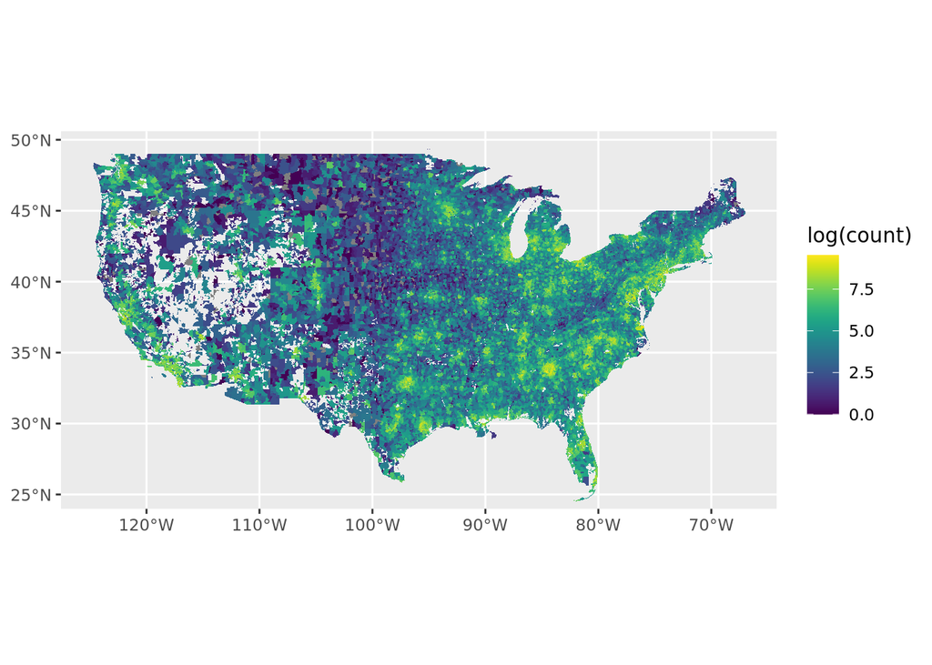

```r
ggplot(data = data, aes(fill = log(count))) +
  geom_sf(lwd = 0) +
  scale_fill_viridis() +
  xlim(-124.7, -67.1) +
  ylim(25.2, 49.4)
```

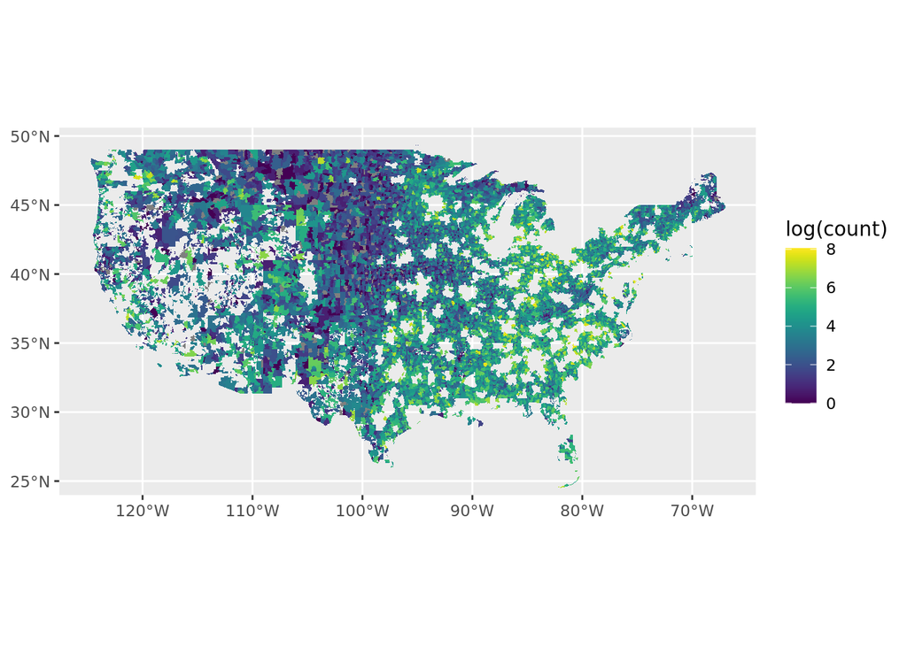

```r
data %>% filter(rural == 1) %>%
ggplot(aes(fill = log(count))) +
  geom_sf(lwd = 0) +
  scale_fill_viridis() +
  xlim(-124.7, -67.1) +
  ylim(25.2, 49.4)
```

```r
va_rural_zips <- uszips %>% filter(state_name == "Virginia" & county_name == "Caroline") %>% pull(zip)
ok_rural_zips <- uszips %>% filter(state_name == "Oklahoma" & county_name == "Comanche") %>% pull(zip)

va_rural_ids <- pers %>% filter(zipcode %in% va_rural_zips) %>% pull(id)
ok_rural_ids <- pers %>% filter(zipcode %in% ok_rural_zips) %>% pull(id)

con <- get_db_conn()
rural_va_job <- DBI::dbGetQuery(con, paste("SELECT * FROM bgt_res.job WHERE id IN (", paste(va_rural_ids, collapse = ", "), ")"))
rural_ok_job <- DBI::dbGetQuery(con, paste("SELECT * FROM bgt_res.job WHERE id IN (", paste(ok_rural_ids, collapse = ", "), ")"))
DBI::dbDisconnect(con)
```

```
## [1] TRUE
```

```r
data_profiling(rural_va_job)
```

```
## # A tibble: 9 x 5
##   var         variable_type num_unique num_missing perc_missing
##   <chr>       <chr>              <int>       <int>        <dbl>
## 1 id          integer             1783           0          0
## 2 onet        character            505        2464         23.2
## 3 jobposition integer               57        1334         12.6
## 4 state       character            222        4420         41.6
## 5 city        character            942        4462         42.0
## 6 county      character              6       10456         98.3
## 7 sector      character             21        6157         57.9
## 8 startdate   Date                 655        1702         16.0
## 9 enddate     Date                 624        1702         16.0
```

```r
data_profiling(rural_ok_job)
```

```
## # A tibble: 9 x 5
##   var         variable_type num_unique num_missing perc_missing
##   <chr>       <chr>              <int>       <int>        <dbl>
## 1 id          integer             8479           0          0
## 2 onet        character            729       10598         25.3
## 3 jobposition integer               43        5535         13.2
## 4 state       character            522       16164         38.6
## 5 city        character           2824       16007         38.3
## 6 county      character             10       41180         98.4
## 7 sector      character             21       20951         50.1
## 8 startdate   Date                1684        6129         14.6
## 9 enddate     Date                1576        6129         14.6
```

```r
military <- "55-[0-9][0-9][0-9][0-9].[0-9][0-9]"

## 33 veterans
rural_va_job %>% mutate(military = ifelse(str_detect(onet, military), "military", "nonmilitary")) %>% filter(military == "military") %>% distinct(id)
```

```
##           id
## 1    8200351
## 2   13869679
## 3   15677485
## 4   17076687
## 5   16652800
## 6   18150651
## 7   20135624
## 8   20233640
## 9   22336922
## 10  24858061
## 11  30663456
## 12  32925437
## 13  48554056
## 14  33913799
```

[output cut: 19 more lines]

```r
## 232 veterans
rural_ok_job %>% mutate(military = ifelse(str_detect(onet, military), "military", "nonmilitary")) %>% filter(military == "military") %>% distinct(id)
```

```
##            id
## 1      172189
## 2      586974
## 3      649322
## 4      713447
## 5      732978
## 6      735926
## 7      744705
## 8     2033940
## 9     2189293
## 10    2233687
## 11    2262624
## 12    2283693
## 13    2477510
## 14    2478684
```

[output cut: 218 more lines]

```r
# 1783 overall
rural_va_job %>% distinct(id)
```

```
##             id
## 1     10416763
## 2     19326709
## 3     20561768
## 4      1574470
## 5      1772854
## 6     10467024
## 7      8572341
## 8     13964217
## 9     17614940
## 10     1795829
## 11    20318776
## 12    16652800
## 13    19731141
## 14    31480667
```

[output cut: 1769 more lines]

```r
# 8479 overall
rural_ok_job %>% distinct(id)
```

```
##             id
## 1        27926
## 2        31270
## 3        45637
## 4        49169
## 5        50913
## 6        56960
## 7        62414
## 8        66855
## 9        67901
## 10       86718
## 11       89625
## 12       93467
## 13       97053
## 14      102113
```

[output cut: 8465 more lines]

```r
military_onets <- c("55-1011.00", "55-1012.00", "55-1013.00", "55-1014.00", "55-1015.00", "55-1016.00", "55-1017.00", "55-1019.00", "55-2011.00", "55-2012.00", "55-2013.00", "55-3011.00"," 55-3012.00", "55-3013.00", "55-3014.00", "55-3015.00", "55-3016.00", "55-3017.00", "55-3018.00", "55-3019.00")

con <- get_db_conn()
job <- DBI::dbGetQuery(con, paste("SELECT * FROM bgt_res.job WHERE onet LIKE '55-%'"))
DBI::dbDisconnect(con)
```

```
## [1] TRUE
```

```r
ids <- job %>% distinct(id) %>% pull(id)

zips <- pers %>% filter(id %in% ids) %>% group_by(zipcode) %>%
  mutate(zip = str_extract(zipcode, "^[0-9][0-9][0-9][0-9][0-9]")) %>%
  group_by(zip) %>%
  mutate(count = n()) %>% summarise(sum = sum(count))
fw_zips <- zctas()
```

```
## ZCTAs can take several minutes to download.  To cache the data and avoid re-downloading in future R sessions, set `options(tigris_use_cache = TRUE)`
```

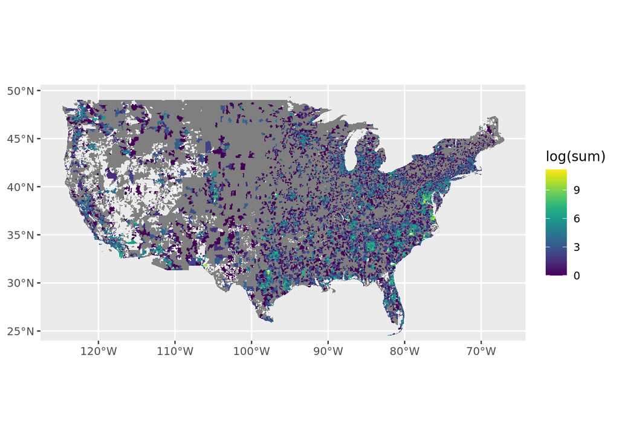

```r
data <- left_join(fw_zips, zips, by = c("GEOID10" = "zip"))

ggplot(data = data, aes(fill = log(sum))) +
  geom_sf(lwd = 0) +
  scale_fill_viridis() +
  xlim(-124.7, -67.1) +
  ylim(25.2, 49.4)
```